# Cox vs GLM Approximation: Null Operating Characteristics

- Show All Code
- Hide All Code
- View Source

Threshold Calibration for the GBSG Survival DGM

Author

Larry F. Leon

Published

April 16, 2026

# 1 Introduction

Leon et al. (2024, Section 2.1) approximate the per-subgroup detection probability as:

$$P_1(c_1, c_2; d, \theta) =
P(W_1 + W_2 \ge 2\log c_1, \;\min(W_1, W_2) \ge \log c_2)
\tag{3}$$

with $W_1, W_2 \stackrel{\text{iid}}{\sim} N(\log\theta, 8/d)$.

This document focuses on **null operating characteristics** for the GBSG survival DGM: we evaluate how the false-positive rate (FPR) varies across a grid of $(c_1, c_2)$ threshold pairs to identify the region where the procedure-level FPR is at most 10–12%.

We compare:

- **(B)** GLM approximation (per-subgroup $P_1$ via `compute_detection_probability_glm()`)
- **(C)** Cox ForestSearch simulation
- **(A)** Poisson+offset ForestSearch simulation
- **$L_{\text{eff}}$ correction**: $1 - (1 - P_1)^{L_{\text{eff}}}$

All simulations are under $H_0$ (uniform treatment effect, no subgroup heterogeneity).

## 1.1 Pipeline Overview

The figure below shows the complete workflow across the C3 and S2 documents. C3 (this document) establishes the null operating characteristics and fits the $L_{\text{eff}}$ power law. S2 (`selection_survival_frontier.qmd`) consumes the calibration to sweep a dense threshold grid and select operating points.

[figure not shown]

Figure: Two-document survival calibration pipeline. Left annotations show recommended production simulation budgets. The long arrow crossing the dashed line is the `.rds` handoff.

# 2 Setup

```r
library(forestsearch)
library(weightedsurv)
library(data.table)
library(survival)
library(ggplot2)
library(patchwork)
library(gt)
library(foreach)
library(doFuture)
library(future)

# -- Safe foreach result collection -------------------------------------------
# Replaces .errorhandling = "remove" (which silently drops failures)
# with .errorhandling = "pass" + post-hoc separation of errors from results.
collect_results <- function(raw_list, label = "") {
  is_err <- vapply(raw_list, inherits, logical(1), "error")
  n_failed <- sum(is_err)
  if (n_failed > 0) {
    err_msgs <- vapply(raw_list[is_err], conditionMessage, character(1))
    warning(sprintf("%s%d of %d tasks failed.",
        if (nzchar(label)) paste0(label, ": ") else "",
        n_failed, length(raw_list)))
    message("  First errors:\n    ",
        paste(head(unique(err_msgs), 3), collapse = "\n    "))
  }
  good <- raw_list[!is_err]
  if (length(good) == 0) {
    result <- NULL
  } else if (requireNamespace("data.table", quietly = TRUE)) {
    result <- data.table::rbindlist(good, use.names = TRUE, fill = TRUE)
    result <- as.data.frame(result)
  } else {
    result <- do.call(rbind, good)
  }
  attr(result, "n_failed") <- n_failed
  attr(result, "n_total") <- length(raw_list)
  result
}


# L_eff save/load helpers
#source(here::here("../R", "leff_calibration_io.R"))
plan(multisession, workers = n_workers)
cat("Using", n_workers, "parallel workers\n")
```

```
#> Using 13 parallel workers
```

```r
cat("H0 sims per config:", nsims_null, "\n")
```

```
#> H0 sims per config: 2000
```

```r
timings <- list()
t_vignette_start <- proc.time()
```

# 3 Null DGM

```r
t0 <- proc.time()[3]

dgm_null <- setup_gbsg_dgm(model = "null", k_treat = 1.0, verbose = TRUE)
```

```
#> === GBSG DGM Creation (Aligned) ===
```

```
#> Model type: null
```

```
#> Effect modifiers: k_treat = 1.000, k_inter = 1.000, k_z3 = 1.000
```

```
#> Sample size: 686
```

```
#> Events: 299 (43.6%)
```

```
#> Harm subgroup size: 0 (0.0%)
```

```
#> ER threshold (z1_quantile = 0.25): 8.0
```

```
#>
#> --- Original AFT Coefficients ---
```

```
#> sigma (scale): 0.7151
```

```
#> mu (intercept): 4.4590
```

```
#> gamma coefficients:
```

```
#>   treat: 0.3034
```

```
#>   z1: -0.0411
```

```
#>   z2: -0.0393
```

```
#>   z3: -0.0118
```

```
#>   z4: 0.2464
```

```
#>   z5: -0.3234
```

```
#>
#> --- Modified AFT Coefficients ---
```

```
#> gamma['treat']: 0.3034 -> 0.3034 (k_treat = 1.000)
```

```
#> gamma['z3']: -0.0118 -> -0.0118 (k_z3 = 1.000)
```

```
#>
#> --- Hazard Ratios (Stacked Potential Outcomes) ---
```

```
#> HR (overall/causal): 0.7223
```

```
#> HR (harm subgroup, H): NA
```

```
#> HR (complement, Hc): 0.7223
```

```
#>
#> --- Average Hazard Ratios (from loghr_po) ---
```

```
#> AHR (overall): 0.6543
```

```
#> AHR (harm subgroup, H): NA
```

```
#> AHR (complement, Hc): 0.6543
```

```r
cat("\nNull DGM:\n")
```

```
#>
#> Null DGM:
```

```r
cat("  HR(ITT):", round(dgm_null$hr_causal, 3), "\n")
```

```
#>   HR(ITT): 0.722
```

```r
cat("  AHR:", round(dgm_null$AHR, 3), "\n")
```

```
#>   AHR: 0.654
```

```r
timings$dgm <- proc.time()[3] - t0
```

# 4 Part I: Per-Subgroup Approximation

Instant calculations — no simulation required.

```r
# Shorthand wrapper for compute_detection_probability_glm()
p_detect_glm <- function(theta, d_eff, c1, c2) {
  compute_detection_probability_glm(
    theta = theta, d_eff = d_eff, c1 = c1, c2 = c2,
    effect_scale = "ratio", method = "monte_carlo"
  )
}
```

## 4.1 Per-Subgroup Approximation

```r
# Reference subgroup: n_H = n.min (from setup)
n_H_dgm <- n_min_val
d_dgm   <- round(d_eff_survival(n_H_dgm, prop_cens))

approx_null <- expand.grid(c1 = c1_grid, c2 = c2_grid,
                            stringsAsFactors = FALSE)
approx_null <- approx_null[approx_null$c2 <= approx_null$c1, ]
approx_null$P1 <- mapply(function(c1v, c2v)
  round(p_detect_glm(1.0, d_dgm, c1v, c2v), 4),
  approx_null$c1, approx_null$c2)

cat(sprintf("d_eff = %d (n_H=%d, prop_cens=%.2f) | %d valid (c1,c2) pairs\n",
            d_dgm, n_H_dgm, prop_cens, nrow(approx_null)))
```

```
#> d_eff = 32 (n_H=60, prop_cens=0.46) | 63 valid (c1,c2) pairs
```

```r
cat(sprintf("P1 range: %.3f -- %.3f (paper default c1=1.25, c2=1.0: %.3f)\n",
            min(approx_null$P1), max(approx_null$P1),
            approx_null$P1[approx_null$c1 == 1.25 & approx_null$c2 == 1.00]))
```

```
#> P1 range: 0.082 -- 0.437 (paper default c1=1.25, c2=1.0: 0.194)
```

## 4.2 Per-Subgroup Approximation Heatmap

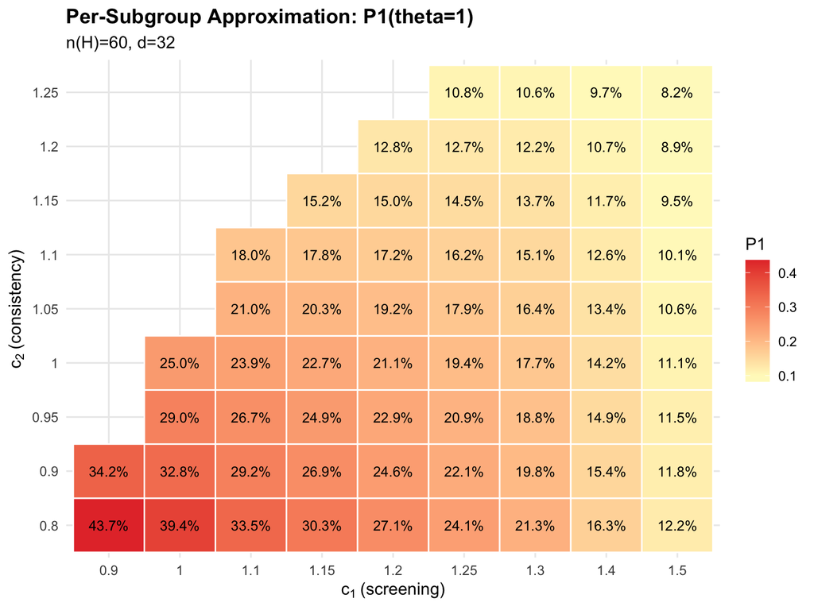

Per-subgroup P1(theta=1) heatmap. This is the single-subgroup probability; the procedure-level FPR is evaluated by simulation below.

```r
ggplot(approx_null, aes(x = factor(c1), y = factor(c2), fill = P1)) +
  geom_tile(colour = "white", linewidth = 0.5) +
  geom_text(aes(label = sprintf("%.1f%%", 100 * P1)),
            size = 3.5, colour = "black") +
  scale_fill_gradient2(
    low = "#E8F5E9", mid = "#FFF9C4", high = "#E53935",
    midpoint = 0.10, name = "P1"
  ) +
  labs(x = expression(c[1] ~ "(screening)"),
       y = expression(c[2] ~ "(consistency)"),
       title = "Per-Subgroup Approximation: P1(theta=1)",
       subtitle = sprintf("n(H)=%d, d=%d", n_H_dgm, d_dgm)) +
  theme_minimal(base_size = 12) +
  theme(plot.title = element_text(face = "bold"))
```

# 5 Part II: Null Simulations

## 5.1 Simulation Parameters

```r
# Build compound parameter objects from setup-chunk scalars
fs_params_base <- list(
  hr.threshold = fs_hr_threshold,
  hr.consistency = fs_hr_consistency,
  pconsistency.threshold = pcons,
  fs.splits = fs_splits,
  n.min = n_min_val,
  d0.min = fs_d0_min, d1.min = fs_d1_min,
  maxk = maxk_val, by.risk = fs_by_risk,
  vi.grf.min = fs_vi_grf_min,
  use_lasso = TRUE, use_grf = TRUE,
  use_twostage = TRUE, twostage_args = list(),
    parallel_args = list(plan="sequential", workers = 1, show_message = FALSE)
)

fs_params_cox <- modifyList(fs_params_base, list(
  outcome.name = "y_sim", event.name = "event_sim",
  treat.name = "treat_sim", id.name = "id"
))


fs_params_irr <- modifyList(fs_params_base, list(
  outcome.name = "event_sim",   # binary event indicator (0/1)
  event.name = "event_sim",
  treat.name = "treat_sim", id.name = "id",
  outcome_type = "binary", effect_measure = "IRR",
  offset.name = "y_sim",        # follow-up time for log(time) offset
  dmin.grf = 0.0
))

sim_config <- list(
  n_sample = n_sample,
  analysis_time = analysis_time,
  seed_base = sim_seed,
  cens_adjust = cens_adjust
)

cat("Simulation config:\n")
```

```
#> Simulation config:
```

```r
cat("  H0 sims:", nsims_null, "\n")
```

```
#>   H0 sims: 2000
```

```r
cat("  N:", sim_config$n_sample, "\n")
```

```
#>   N: 700
```

```r
cat("  analysis_time:", sim_config$analysis_time, "months\n")
```

```
#>   analysis_time: 84 months
```

```r
cat("  n.min:", fs_params_base$n.min, "(paper default)\n")
```

```
#>   n.min: 60 (paper default)
```

## 5.2 Cox PH Null Simulations (Paper Defaults)

```r
cat("Running Cox H0 simulations (c1=1.25, c2=1.0)...\n")
```

```
#> Running Cox H0 simulations (c1=1.25, c2=1.0)...
```

```r
t0 <- proc.time()[3]

results_null_cox_raw <- foreach(
  sim = seq_len(nsims_null),
  .errorhandling = "pass",
  .options.future = list(
    packages = c("forestsearch", "survival", "data.table", "future"),
    seed = TRUE)
) %dofuture% {
  future::plan("sequential")
  run_simulation_analysis(
    sim_id = sim, dgm = dgm_null,
    n_sample = sim_config$n_sample,
    analysis_time = sim_config$analysis_time,
    cens_adjust = sim_config$cens_adjust,
    confounders_base = confounders_base,
    cox_formula_adj = cox_formula_adj,
    n_add_noise = 0L,
    run_fs = TRUE, run_fs_grf = FALSE, run_grf = FALSE,
    fs_params = fs_params_cox, verbose = FALSE
  )
}
timings$null_cox <- proc.time()[3] - t0
results_null_cox <- collect_results(results_null_cox_raw, "Cox H0")
if (nrow(results_null_cox) < nsims_null) {
  warning(sprintf(
    "Cox H0: %d of %d tasks silently failed.",
    nsims_null - nrow(results_null_cox), nsims_null
  ))
}
cat("Cox H0:", round(timings$null_cox / 60, 1), "min |",
    nrow(results_null_cox), "/", nsims_null, "rows\n")
```

```
#> Cox H0: 6.7 min | 2000 / 2000 rows
```

```r
# Reset workers to prevent memory accumulation
future::plan("sequential"); gc(verbose = FALSE)
```

```
#>           used  (Mb) gc trigger  (Mb) limit (Mb) max used  (Mb)
#> Ncells 2797237 149.4    4746545 253.5         NA  4746545 253.5
#> Vcells 5258587  40.2   12267447  93.6      36864 12262214  93.6
```

```r
future::plan("multisession", workers = n_workers)
```

## 5.3 Poisson IRR Null Simulations (Paper Defaults)

```r
cat("Running Poisson IRR H0 simulations (c1=1.25, c2=1.0)...\n")
```

```
#> Running Poisson IRR H0 simulations (c1=1.25, c2=1.0)...
```

```r
t0 <- proc.time()[3]

results_null_irr_raw <- foreach(
  sim = seq_len(nsims_null),
  .errorhandling = "pass",
  .options.future = list(
    packages = c("forestsearch", "survival", "data.table", "future"),
    seed = TRUE)
) %dofuture% {
  future::plan("sequential")
  run_simulation_analysis(
    sim_id = sim, dgm = dgm_null,
    n_sample = sim_config$n_sample,
    analysis_time = sim_config$analysis_time,
    cens_adjust = sim_config$cens_adjust,
    confounders_base = confounders_base,
    cox_formula_adj = cox_formula_adj,
    n_add_noise = 0L,
    run_fs = TRUE, run_fs_grf = FALSE, run_grf = FALSE,
    fs_params = fs_params_irr, verbose = FALSE
  )
}
timings$null_irr <- proc.time()[3] - t0
results_null_irr <- collect_results(results_null_irr_raw, "IRR H0")
if (nrow(results_null_irr) < nsims_null) {
  warning(sprintf(
    "IRR H0: %d of %d tasks silently failed.",
    nsims_null - nrow(results_null_irr), nsims_null
  ))
}
cat("IRR H0:", round(timings$null_irr / 60, 1), "min |",
    nrow(results_null_irr), "/", nsims_null, "rows\n")
```

```
#> IRR H0: 7.2 min | 2000 / 2000 rows
```

```r
# Reset workers before calibration phases
future::plan("sequential"); gc(verbose = FALSE)
```

```
#>           used  (Mb) gc trigger  (Mb) limit (Mb) max used  (Mb)
#> Ncells 2877875 153.7    4746545 253.5         NA  4746545 253.5
#> Vcells 5554037  42.4   12267447  93.6      36864 12262214  93.6
```

```r
future::plan("multisession", workers = n_workers)
```

## 5.4 Baseline H0 Comparison: Cox vs Poisson (Paper Defaults)

```r
cox_h0 <- results_null_cox[results_null_cox$analysis == "FS", ]
irr_h0 <- results_null_irr[results_null_irr$analysis == "FS", ]

P1_default <- p_detect_glm(1.0, d_dgm, 1.25, 1.0)

baseline_h0 <- data.frame(
  Metric = c("Simulated FPR", "Per-subgroup P1", "Sim/P1 Ratio",
             "N sims"),
  `Cox PH` = c(
    round(mean(cox_h0$any.H), 4),
    round(P1_default, 4),
    round(mean(cox_h0$any.H) / P1_default, 2),
    nrow(cox_h0)
  ),
  `Poisson IRR` = c(
    round(mean(irr_h0$any.H), 4),
    round(P1_default, 4),
    round(mean(irr_h0$any.H) / P1_default, 2),
    nrow(irr_h0)
  ),
  check.names = FALSE
)

gt(baseline_h0) |>
  tab_header(
    title = md("**H0 Baseline: Cox vs Poisson (c1=1.25, c2=1.0)**"),
    subtitle = sprintf("N=%d, %d sims, HR(ITT)=%.2f",
      sim_config$n_sample, nsims_null,
      dgm_null$hr_causal)
  )
```

H0 comparison at paper defaults (c1=1.25, c2=1.0)

**H0 Baseline: Cox vs Poisson (c1=1.25, c2=1.0)**

N=700, 2000 sims, HR(ITT)=0.72

| Metric | Cox PH | Poisson IRR |
| --- | --- | --- |
| Simulated FPR | 0.0595 | 0.1505 |
| Per-subgroup P1 | 0.1944 | 0.1944 |
| Sim/P1 Ratio | 0.3100 | 0.7700 |
| N sims | 2000.0000 | 2000.0000 |

# 6 Part III: $L_{\text{eff}}$ Calibration

## 6.1 Multi-N Null Simulations

```r
n_sims_cal <- nsims_cal

cat("Running multi-N null calibration simulations...\n")
```

```
#> Running multi-N null calibration simulations...
```

```r
if (n_sims_cal < nsims_null) {
  cat(sprintf("  Note: using nsims_cal = %d (not nsims_null = %d).\n",
              n_sims_cal, nsims_null))
  cat("  For higher precision, increase nsims_cal in the setup chunk.\n")
  cat("  For production-grade calibration, use C2 instead.\n")
}
```

```
#>   Note: using nsims_cal = 1000 (not nsims_null = 2000).
#>   For higher precision, increase nsims_cal in the setup chunk.
#>   For production-grade calibration, use C2 instead.
```

```r
cat(sprintf("N values: %s | Sims per N: %d\n",
            paste(N_cal_values, collapse = ", "), n_sims_cal))
```

```
#> N values: 300, 500, 700 | Sims per N: 1000
```

```r
t0 <- proc.time()[3]

cal_results <- list()
for (N_val in N_cal_values) {
  t_N <- proc.time()[3]

  res_N_raw <- foreach(
    sim = seq_len(n_sims_cal),
    .errorhandling = "pass",
    .options.future = list(
      packages = c("forestsearch", "survival", "data.table", "future"),
      seed = TRUE)
  ) %dofuture% {
    future::plan("sequential")
    run_simulation_analysis(
      sim_id = sim, dgm = dgm_null,
      n_sample = N_val,
      analysis_time = sim_config$analysis_time,
      cens_adjust = sim_config$cens_adjust,
      confounders_base = confounders_base,
      cox_formula_adj = cox_formula_adj,
      n_add_noise = 0L,
      run_fs = TRUE, run_fs_grf = FALSE, run_grf = FALSE,
      fs_params = fs_params_cox, verbose = FALSE
    )
  }

  res_N <- collect_results(res_N_raw, sprintf("cal N=%d", N_val))
  fs_rows <- res_N[res_N$analysis == "FS", ]
  if (nrow(fs_rows) < n_sims_cal) {
    warning(sprintf(
      "Calibration N=%d: %d of %d tasks silently failed.",
      N_val, n_sims_cal - nrow(fs_rows), n_sims_cal
    ))
  }
  fpr_N <- mean(fs_rows$any.H, na.rm = TRUE)

  cal_results[[as.character(N_val)]] <- data.frame(
    N = N_val, sim_fpr = fpr_N, n_sims = nrow(fs_rows)
  )

  cat(sprintf("  N = %4d: FPR = %.3f (%d sims) | %.1f sec\n",
      N_val, fpr_N, nrow(fs_rows), proc.time()[3] - t_N))
}
```

```
#>   N =  300: FPR = 0.062 (1000 sims) | 91.4 sec
#>   N =  500: FPR = 0.066 (1000 sims) | 151.3 sec
#>   N =  700: FPR = 0.058 (1000 sims) | 201.5 sec
```

```r
cal_df <- do.call(rbind, cal_results)
timings$null_cal <- proc.time()[3] - t0
cat(sprintf("Multi-N calibration: %.1f min\n", timings$null_cal / 60))
```

```
#> Multi-N calibration: 7.4 min
```

```r
# Free workers before L_eff fitting (re-established before grid phase)
future::plan("sequential"); gc(verbose = FALSE)
```

```
#>           used  (Mb) gc trigger  (Mb) limit (Mb) max used  (Mb)
#> Ncells 3034078 162.1    4746545 253.5         NA  4746545 253.5
#> Vcells 6078980  46.4   12267447  93.6      36864 12262214  93.6
```

## 6.2 Implied $L_{\text{eff}}$ from Simulation

For each $N$, solve for the implied $L_{\text{eff}}$:

$$L_{\text{eff}} =
\frac{\log(1 - \text{FPR}_{\text{sim}})}
{\log(1 - P_1)}$$

```r
cal_df$n_H <- n_min_val
cal_df$d_eff <- round(d_eff_survival(cal_df$n_H, prop_cens))
cal_df$P1 <- sapply(cal_df$d_eff, function(d) {
  p_detect_glm(1.0, d, 1.25, 1.0)
})
cal_df$L_eff <- log(1 - cal_df$sim_fpr) / log(1 - cal_df$P1)

cat("=== Implied L_eff ===\n")
```

```
#> === Implied L_eff ===
```

```r
print(cal_df[, c("N", "n_H", "d_eff", "P1", "sim_fpr", "L_eff")])
```

```
#>       N n_H d_eff       P1 sim_fpr     L_eff
#> 300 300  60    32 0.194358   0.062 0.2961622
#> 500 500  60    32 0.194358   0.066 0.3159364
#> 700 700  60    32 0.194358   0.058 0.2764722
```

## 6.3 Fit $L_{\text{eff}}$ Power Law

```
#> L_eff Calibration
#>   Model: L_eff = 0.338 * (N / 60)^-0.064
#>   R-squared: 0.169
#>   Calibrated at N = 300, 500, 700
#>
#>   Implied L_eff:
#>     N =  300: L_eff = 0.30 (fitted: 0.30)
#>     N =  500: L_eff = 0.32 (fitted: 0.29)
#>     N =  700: L_eff = 0.28 (fitted: 0.29)
```

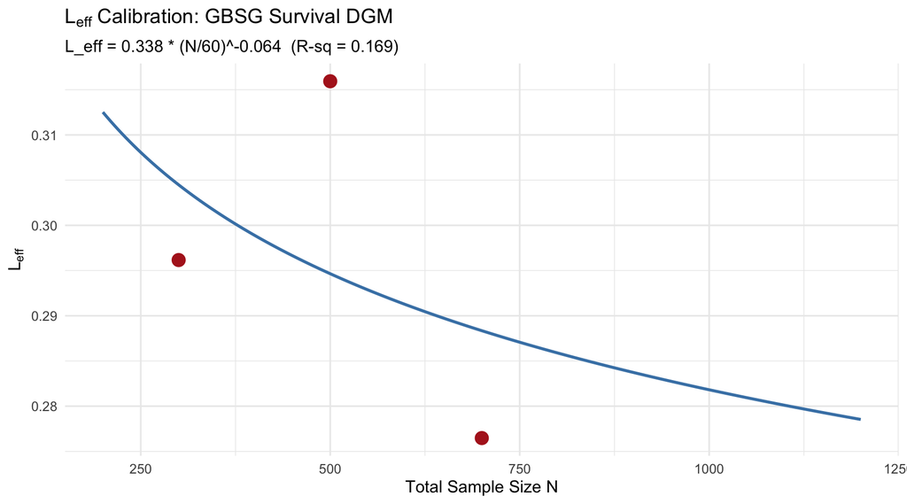

Implied L_eff with power-law fit for the GBSG survival DGM.

```r
# Fit power law
cal_valid <- cal_df[cal_df$sim_fpr > 0 & cal_df$P1 > 0 &
                     is.finite(cal_df$L_eff), ]

if (nrow(cal_valid) >= 2) {
  leff_cal <- calibrate_L_eff(
    N = cal_valid$N, P1 = cal_valid$P1,
    sim_fpr = cal_valid$sim_fpr, n_min = n_min_val
  )
  print(leff_cal)

  C_fit <- leff_cal$C
  alpha_fit <- leff_cal$alpha

  N_pred <- seq(200, 1200, by = 5)
  pred_curve <- data.frame(
    N = N_pred, L_eff = C_fit * (N_pred / n_min_val)^alpha_fit
  )

  print(
    ggplot() +
      geom_point(data = cal_valid, aes(x = N, y = L_eff),
                 size = 4, colour = "firebrick") +
      geom_line(data = pred_curve, aes(x = N, y = L_eff),
                colour = "steelblue", linewidth = 1) +
      labs(x = "Total Sample Size N",
           y = expression(L[eff]),
           title = expression(L[eff] * " Calibration: GBSG Survival DGM"),
           subtitle = sprintf("L_eff = %.3f * (N/%d)^%.3f  (R-sq = %.3f)",
                               C_fit, n_min_val, alpha_fit,
                               leff_cal$r_squared)) +
      theme_minimal(base_size = 12) +
      theme(plot.title = element_text(face = "bold"))
  )
} else {
  cat("Insufficient calibration points. Using L_eff = 1.\n")
  C_fit <- 1; alpha_fit <- 0
}
```

```r
cat(sprintf("\nFitted model: L_eff = %.3f * (N/%d)^%.3f\n",
            C_fit, n_min_val, alpha_fit))
```

```
#>
#> Fitted model: L_eff = 0.338 * (N/60)^-0.064
```

```r
cat(sprintf("  N = 300:  L_eff = %.2f\n", C_fit * (300/n_min_val)^alpha_fit))
```

```
#>   N = 300:  L_eff = 0.30
```

```r
cat(sprintf("  N = 500:  L_eff = %.2f\n", C_fit * (500/n_min_val)^alpha_fit))
```

```
#>   N = 500:  L_eff = 0.29
```

```r
cat(sprintf("  N = 700:  L_eff = %.2f\n", C_fit * (700/n_min_val)^alpha_fit))
```

```
#>   N = 700:  L_eff = 0.29
```

## 6.4 Save Calibration

```r
# Save calibration to .rds for downstream documents (S2)
save_leff_calibration(
  C = C_fit,
  alpha = alpha_fit,
  n_min = n_min_val,
  outcome_type = "survival",
  cal_data = cal_df,
  dgm_description = paste(
    "GBSG survival DGM,", length(confounders_base), "confounders",
    paste0("(", paste(confounders_base, collapse = ", "), "),"),
    sprintf("prop_cens=%.2f, p_harm=%.2f", prop_cens, p_harm)),
  n_sims_per_N = n_sims_cal,
  output_dir = output_dir,
  extra = list(
    # ForestSearch config (S2 should match these)
    confounders_base = confounders_base,
    prop_cens        = prop_cens,
    p_harm           = p_harm,
    hr_h1            = hr_h1,
    pcons            = pcons,
    fs_splits        = fs_splits,
    maxk_val         = maxk_val,
    n_min_val        = n_min_val,
    analysis_time    = analysis_time,
    cens_adjust      = cens_adjust,
    fpr_target       = fpr_target,
    N_cal_values     = N_cal_values,
    # Grid range validated for L_eff threshold-independence
    c1_range = range(c1_grid),
    c2_range = range(c2_grid)
  )
)
```

```
#> L_eff calibration saved: ../_data/calibration_survival_leff.rds
```

```
#>   outcome: survival | C = 0.3377 | alpha = -0.0643 | n_min = 60
```

```
#>   Size: 0.8 KB
```

**ImportantShared `.rds` With C2**

Both this document (C3) and `calibration_survival_fourway.qmd` (C2) save to `calibration_survival_leff.rds`. **C2 is the primary source** (up to 20K replicates per N). C3 uses fewer replicates and is designed as a faster grid sweep. If both are rendered, the last-rendered file wins. To avoid overwriting C2’s calibration, set `recalibrate = FALSE` in this document or render C2 after C3.

## 6.5 Corrected Baseline

```r
L_eff_main <- C_fit * (n_sample / n_min_val)^alpha_fit
P1_cox <- p_detect_glm(1.0, d_dgm, 1.25, 1.0)
fpr_corr <- 1 - (1 - P1_cox)^L_eff_main

cat(sprintf("=== Corrected Baseline (N=%d, c1=1.25, c2=1.0) ===\n",
            n_sample))
```

```
#> === Corrected Baseline (N=700, c1=1.25, c2=1.0) ===
```

```r
cat(sprintf("  L_eff:         %.2f\n", L_eff_main))
```

```
#>   L_eff:         0.29
```

```r
cat(sprintf("  P1 (uncorr):   %.3f\n", P1_cox))
```

```
#>   P1 (uncorr):   0.194
```

```r
cat(sprintf("  FPR (corr):    %.3f\n", fpr_corr))
```

```
#>   FPR (corr):    0.060
```

```r
cat(sprintf("  Sim FPR (Cox): %.3f\n", mean(cox_h0$any.H)))
```

```
#>   Sim FPR (Cox): 0.059
```

```r
cat(sprintf("  Sim FPR (IRR): %.3f\n", mean(irr_h0$any.H)))
```

```
#>   Sim FPR (IRR): 0.150
```

```r
cat(sprintf("  Sim/Corr:      %.2f\n",
            mean(cox_h0$any.H) / max(fpr_corr, 0.001)))
```

```
#>   Sim/Corr:      0.98
```

# 7 Part IV: Null Threshold Grid

Systematic evaluation of $(c_1, c_2)$ pairs under $H_0$ at $N = 700$ to identify the region where FPR $\le$ 12%.

Grid defined in the setup chunk: `c1_grid` and `c2_grid`.

## 7.1 Grid Design

```r
grid_pairs <- expand.grid(c1 = c1_grid, c2 = c2_grid,
                           stringsAsFactors = FALSE)
grid_pairs <- grid_pairs[grid_pairs$c2 <= grid_pairs$c1, ]

N_grid     <- n_sample

cat(sprintf("Null grid: %d (c1,c2) pairs x %d sims = %d tasks at N = %d\n",
    nrow(grid_pairs), nsims_grid,
    nrow(grid_pairs) * nsims_grid, N_grid))
```

```
#> Null grid: 63 (c1,c2) pairs x 2000 sims = 126000 tasks at N = 700
```

```r
if (nsims_grid < nsims_null) {
  cat(sprintf("  Note: using nsims_grid = %d (not nsims_null = %d).\n",
              nsims_grid, nsims_null))
  cat("  To increase grid precision, raise nsims_grid in the setup chunk.\n")
}
cat(sprintf("(c1 range: %.2f--%.2f, c2 range: %.2f--%.2f)\n",
    min(c1_grid), max(c1_grid), min(c2_grid), max(c2_grid)))
```

```
#> (c1 range: 0.90--1.50, c2 range: 0.80--1.25)
```

## 7.2 Run Grid Simulations

```r
# Reset workers before grid phase
future::plan("sequential"); gc(verbose = FALSE)
```

```
#>           used  (Mb) gc trigger  (Mb) limit (Mb) max used  (Mb)
#> Ncells 3045795 162.7    4746545 253.5         NA  4746545 253.5
#> Vcells 6106579  46.6   12267447  93.6      36864 12262214  93.6
```

```r
future::plan("multisession", workers = n_workers)

t0 <- proc.time()[3]

grid_tasks <- do.call(rbind, lapply(seq_len(nrow(grid_pairs)), function(g) {
  data.frame(
    grid_id = g, sim = seq_len(nsims_grid),
    c1 = grid_pairs$c1[g], c2 = grid_pairs$c2[g],
    stringsAsFactors = FALSE
  )
}))

cat(sprintf("Running %d null grid tasks...\n", nrow(grid_tasks)))
```

```
#> Running 126000 null grid tasks...
```

```r
grid_results_raw <- foreach(
  i = seq_len(nrow(grid_tasks)),
  .errorhandling = "pass",
  .options.future = list(
    packages = c("forestsearch", "survival", "data.table", "future"),
    seed = TRUE)
) %dofuture% {
  future::plan("sequential")
  sim_id <- grid_tasks$sim[i]
  c1_val <- grid_tasks$c1[i]
  c2_val <- grid_tasks$c2[i]

  fs_params_grid <- modifyList(fs_params_cox, list(
    hr.threshold = c1_val,
    hr.consistency = c2_val
  ))

  res <- run_simulation_analysis(
    sim_id = sim_id, dgm = dgm_null,
    n_sample = N_grid,
    analysis_time = sim_config$analysis_time,
    cens_adjust = sim_config$cens_adjust,
    confounders_base = confounders_base,
    cox_formula_adj = cox_formula_adj,
    n_add_noise = 0L,
    run_fs = TRUE, run_fs_grf = FALSE, run_grf = FALSE,
    fs_params = fs_params_grid, verbose = FALSE
  )

  fs_row <- res[res$analysis == "FS", ]
  data.frame(
    sim = sim_id, c1 = c1_val, c2 = c2_val,
    any_H = if (nrow(fs_row) > 0) fs_row$any.H[1] else 0L,
    stringsAsFactors = FALSE
  )
}

timings$null_grid <- proc.time()[3] - t0
grid_results <- collect_results(grid_results_raw, "null grid")
n_expected_grid <- nrow(grid_tasks)
n_failed_grid   <- attr(grid_results, "n_failed")
cat(sprintf("Null grid: %.1f min | %d/%d results (%d failed)\n",
    timings$null_grid / 60, nrow(grid_results), n_expected_grid, n_failed_grid))
```

```
#> Null grid: 449.4 min | 126000/126000 results (0 failed)
```

```r
# Free workers before sequential post-processing
future::plan("sequential"); gc(verbose = FALSE)
```

```
#>           used  (Mb) gc trigger  (Mb) limit (Mb) max used  (Mb)
#> Ncells 4807318 256.8    8643237 461.6         NA  6892491 368.1
#> Vcells 9077881  69.3   17841123 136.2      36864 16947783 129.4
```

# 8 Part V: Results

## 8.1 FPR Summary and Best Threshold Pairs

```r
grid_dt  <- data.table(grid_results)
grid_fpr <- grid_dt[, .(
  FPR    = mean(any_H, na.rm = TRUE),
  n_found = sum(any_H, na.rm = TRUE),
  n_sims  = .N
), by = .(c1, c2)]

# Approximations
grid_fpr[, P1 := mapply(function(c1v, c2v)
  p_detect_glm(1.0, d_dgm, c1v, c2v), c1, c2)]
L_eff_N <- C_fit * (N_grid / n_min_val)^alpha_fit
grid_fpr[, FPR_corr      := 1 - (1 - P1)^L_eff_N]
grid_fpr[, Sim_over_P1   := round(FPR / pmax(P1, 0.001), 2)]
grid_fpr[, Sim_over_Corr := round(FPR / pmax(FPR_corr, 0.001), 2)]

# ── Overview summary ─────────────────────────────────────────
fpr_range_str <- function(vals) {
  if (length(vals) == 0 || all(is.na(vals))) return("—")
  sprintf("%.1f–%.1f%%", 100 * min(vals, na.rm = TRUE),
                          100 * max(vals, na.rm = TRUE))
}
fpr_overview <- data.frame(
  Region = c(
    "FPR <= 10%",
    sprintf("10%% < FPR <= %.0f%%", 100 * fpr_target),
    sprintf("FPR > %.0f%%", 100 * fpr_target)
  ),
  `Pairs (n)` = c(
    sum(grid_fpr$FPR <= 0.10),
    sum(grid_fpr$FPR > 0.10 & grid_fpr$FPR <= fpr_target),
    sum(grid_fpr$FPR > fpr_target)
  ),
  `FPR range` = c(
    fpr_range_str(grid_fpr$FPR[grid_fpr$FPR <= 0.10]),
    fpr_range_str(grid_fpr$FPR[grid_fpr$FPR > 0.10 & grid_fpr$FPR <= fpr_target]),
    fpr_range_str(grid_fpr$FPR[grid_fpr$FPR > fpr_target])
  ),
  check.names = FALSE
)

gt(fpr_overview) |>
  tab_header(
    title = md("**Simulated FPR: Grid Overview**"),
    subtitle = sprintf("N=%d | %d sims/pair | n.min=%d | L_eff=%.2f",
                        N_grid, nsims_grid, n_min_val, L_eff_N)
  ) |>
  tab_style(style = list(cell_fill(color = "#E8F5E9"),
                          cell_text(weight = "bold")),
    locations = cells_body(rows = 1)) |>
  tab_style(style = cell_fill(color = "#FFF9C4"),
    locations = cells_body(rows = 2)) |>
  tab_style(style = cell_fill(color = "#FFEBEE"),
    locations = cells_body(rows = 3)) |>
  tab_source_note(sprintf(
    "%d total (c1,c2) pairs | target FPR <= %.0f%% | paper defaults c1=1.25, c2=1.0",
    nrow(grid_fpr), 100 * fpr_target))
```

**Simulated FPR: Grid Overview**

N=700 | 2000 sims/pair | n.min=60 | L_eff=0.29

| Region | Pairs (n) | FPR range |
| --- | --- | --- |
| FPR <= 10% | 46 | 0.9–9.4% |
| 10% < FPR <= 12% | 1 | 11.8–11.8% |
| FPR > 12% | 16 | 12.2–30.9% |

63 total (c1,c2) pairs | target FPR <= 12% | paper defaults c1=1.25, c2=1.0

```r
# ── Best pairs: lowest simulated FPR ─────────────────────────
n_best <- min(10L, nrow(grid_fpr))
best_fpr <- grid_fpr[order(FPR)][seq_len(n_best)]

gt(best_fpr[, .(c1, c2,
    `Sim FPR`  = sprintf("%.1f%%", 100 * FPR),
    `P1`       = sprintf("%.1f%%", 100 * P1),
    `FPR_corr` = sprintf("%.1f%%", 100 * FPR_corr),
    `Sim/Corr` = Sim_over_Corr,
    fpr_num    = FPR)]) |>    # keep numeric for row predicate, hidden below
  tab_header(
    title = md("**Best Threshold Pairs (Lowest Sim FPR)**"),
    subtitle = sprintf(
      "Top %d of %d pairs | paper defaults (c1=1.25, c2=1.0) shown for reference",
      n_best, nrow(grid_fpr))
  ) |>
  tab_style(style = cell_fill(color = "#E8F5E9"),
    locations = cells_body(columns = `Sim FPR`,
      rows = fpr_num <= fpr_target)) |>
  tab_style(style = cell_fill(color = "#FFF9C4"),
    locations = cells_body(columns = `Sim FPR`,
      rows = fpr_num > fpr_target & fpr_num <= fpr_target + 0.05)) |>
  cols_hide(columns = fpr_num) |>
  tab_source_note(sprintf(
    "Green: FPR <= %.0f%% (target). Yellow: within 5pp of target.",
    100 * fpr_target))
```

**Best Threshold Pairs (Lowest Sim FPR)**

Top 10 of 63 pairs | paper defaults (c1=1.25, c2=1.0) shown for reference

| c1 | c2 | Sim FPR | P1 | FPR_corr | Sim/Corr |
| --- | --- | --- | --- | --- | --- |
| 1.25 | 1.25 | 0.9% | 10.8% | 3.2% | 0.26 |
| 1.30 | 1.25 | 0.9% | 10.6% | 3.2% | 0.27 |
| 1.40 | 1.25 | 0.9% | 9.6% | 2.9% | 0.29 |
| 1.50 | 1.25 | 0.9% | 8.2% | 2.4% | 0.35 |
| 1.20 | 1.20 | 1.5% | 12.9% | 3.9% | 0.37 |
| 1.25 | 1.20 | 1.5% | 12.7% | 3.8% | 0.38 |
| 1.30 | 1.20 | 1.5% | 12.2% | 3.7% | 0.39 |
| 1.40 | 1.20 | 1.5% | 10.7% | 3.2% | 0.45 |
| 1.50 | 1.20 | 1.5% | 8.9% | 2.7% | 0.55 |
| 1.15 | 1.15 | 2.1% | 15.2% | 4.6% | 0.44 |

Green: FPR <= 12% (target). Yellow: within 5pp of target.

## 8.2 $L_{\text{eff}}$ Consistency Across Threshold Pairs

```r
grid_fpr[, implied_L_eff := ifelse(
  P1 > 0 & FPR > 0 & FPR < 1,
  log(1 - FPR) / log(1 - P1), NA_real_)]

leff_valid <- grid_fpr[!is.na(implied_L_eff)]
cv_val <- 100 * sd(leff_valid$implied_L_eff) /
           median(leff_valid$implied_L_eff)

cat(sprintf("Calibrated L_eff at N=%d: %.2f\n", N_grid, L_eff_N))
```

```
#> Calibrated L_eff at N=700: 0.29
```

```r
cat(sprintf("Implied L_eff: median=%.2f, range=[%.2f, %.2f], CV=%.0f%%\n",
    median(leff_valid$implied_L_eff),
    min(leff_valid$implied_L_eff),
    max(leff_valid$implied_L_eff), cv_val))
```

```
#> Implied L_eff: median=0.27, range=[0.07, 1.11], CV=108%
```

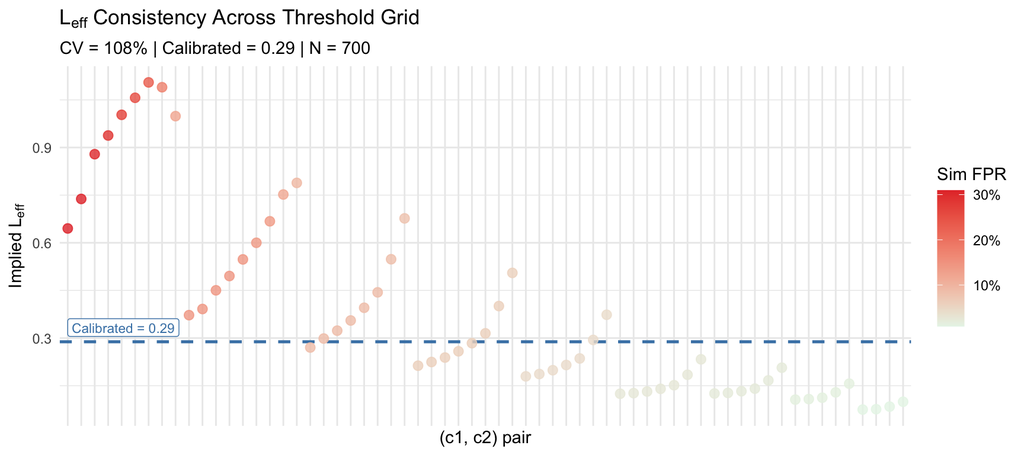

Implied vs calibrated L_eff across all (c1, c2) pairs. Points near the horizontal line support threshold-independence.

```r
if (cv_val > 30) {
  warning(sprintf(
    "CV = %.0f%% > 30%% — L_eff may not be threshold-independent at this grid.",
    cv_val))
} else {
  cat(sprintf("CV = %.0f%% (< 30%%) — threshold-independence assumption holds.\n",
              cv_val))
}
# Scatter: implied vs calibrated, coloured by Sim FPR
ggplot(leff_valid, aes(x = interaction(factor(c1), factor(c2), sep=","),
                        y = implied_L_eff, colour = FPR)) +
  geom_hline(yintercept = L_eff_N, linetype = "dashed",
             colour = "steelblue", linewidth = 0.9) +
  geom_point(size = 2.5, alpha = 0.8) +
  annotate("label", x = 1, y = L_eff_N,
           label = sprintf("Calibrated = %.2f", L_eff_N),
           colour = "steelblue", size = 3, hjust = 0, vjust = -0.3) +
  scale_colour_gradient(low = "#E8F5E9", high = "#E53935",
                         name = "Sim FPR", labels = scales::percent) +
  labs(x = "(c1, c2) pair",
       y = expression("Implied " * L[eff]),
       title = expression(L[eff] * " Consistency Across Threshold Grid"),
       subtitle = sprintf("CV = %.0f%% | Calibrated = %.2f | N = %d",
                           cv_val, L_eff_N, N_grid)) +
  theme_minimal(base_size = 11) +
  theme(axis.text.x = element_blank(),
        axis.ticks.x = element_blank(),
        plot.title = element_text(face = "bold"),
        legend.position = "right")
```

## 8.3 FPR Heatmap

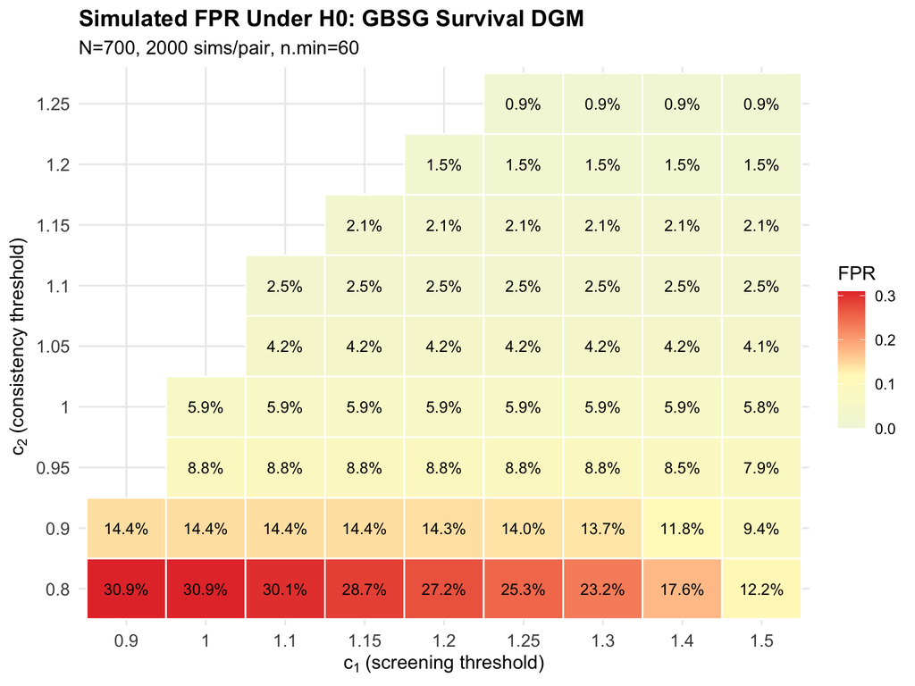

Simulated FPR heatmap by (c1, c2). Values <= 12% are in the acceptable region.

```r
ggplot(grid_fpr, aes(x = factor(c1), y = factor(c2), fill = FPR)) +
  geom_tile(colour = "white", linewidth = 0.5) +
  geom_text(aes(label = sprintf("%.1f%%", 100 * FPR)),
            size = 3.5, colour = "black") +
  scale_fill_gradient2(
    low = "#E8F5E9", mid = "#FFF9C4", high = "#E53935",
    midpoint = fpr_target,
    limits = c(0, max(grid_fpr$FPR, 0.20)),
    name = "FPR"
  ) +
  labs(x = expression(c[1] ~ "(screening threshold)"),
       y = expression(c[2] ~ "(consistency threshold)"),
       title = "Simulated FPR Under H0: GBSG Survival DGM",
       subtitle = sprintf("N=%d, %d sims/pair, n.min=%d",
                           N_grid, nsims_grid, n_min_val)) +
  theme_minimal(base_size = 12) +
  theme(plot.title = element_text(face = "bold"),
        axis.text = element_text(size = 11))
```

## 8.4 FPR Sensitivity to $c_2$ (Fixing $c_1$)

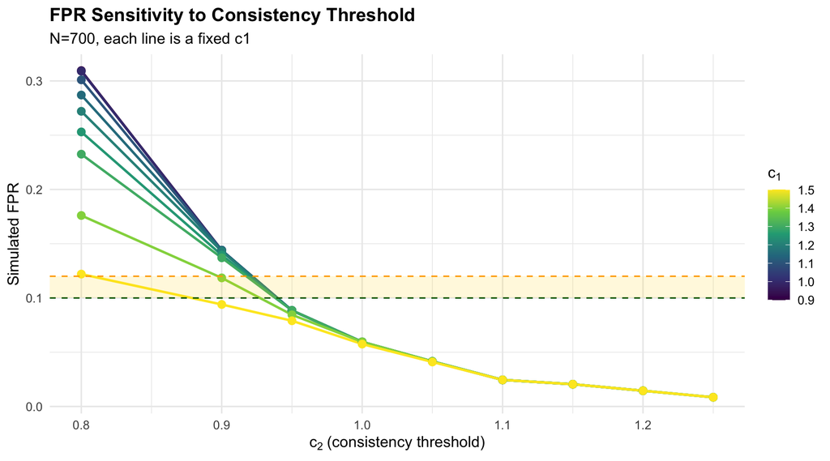

FPR vs c2 for each fixed c1. The target band is highlighted.

```r
ggplot(grid_fpr, aes(x = c2, y = FPR,
                      colour = c1, group = factor(c1))) +
  geom_line(linewidth = 0.9) +
  geom_point(size = 2.5) +
  geom_hline(yintercept = 0.10, linetype = "dashed", colour = "darkgreen") +
  geom_hline(yintercept = fpr_target, linetype = "dashed", colour = "orange") +
  annotate("rect", xmin = -Inf, xmax = Inf,
           ymin = 0.10, ymax = fpr_target,
           alpha = 0.15, fill = "gold") +
  scale_colour_viridis_c(name = expression(c[1]), option = "D") +
  labs(x = expression(c[2] ~ "(consistency threshold)"),
       y = "Simulated FPR",
       title = "FPR Sensitivity to Consistency Threshold",
       subtitle = sprintf("N=%d, each line is a fixed c1", N_grid)) +
  theme_minimal(base_size = 12) +
  theme(legend.position = "right",
        plot.title = element_text(face = "bold"))
```

## 8.5 FPR Sensitivity to $c_1$ (Fixing $c_2$)

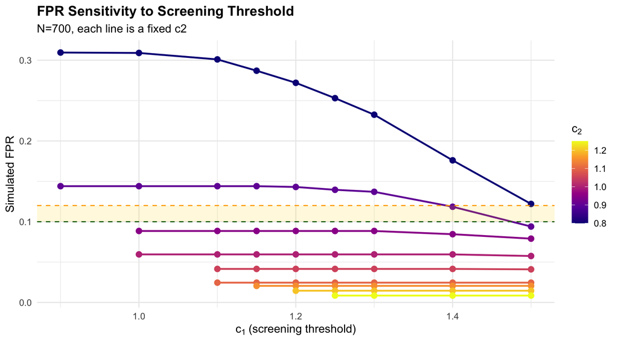

FPR vs c1 for each fixed c2. Shows the screening threshold’s independent effect.

```r
ggplot(grid_fpr, aes(x = c1, y = FPR,
                      colour = c2, group = factor(c2))) +
  geom_line(linewidth = 0.9) +
  geom_point(size = 2.5) +
  geom_hline(yintercept = 0.10, linetype = "dashed", colour = "darkgreen") +
  geom_hline(yintercept = fpr_target, linetype = "dashed", colour = "orange") +
  annotate("rect", xmin = -Inf, xmax = Inf,
           ymin = 0.10, ymax = fpr_target,
           alpha = 0.15, fill = "gold") +
  scale_colour_viridis_c(name = expression(c[2]), option = "C") +
  labs(x = expression(c[1] ~ "(screening threshold)"),
       y = "Simulated FPR",
       title = "FPR Sensitivity to Screening Threshold",
       subtitle = sprintf("N=%d, each line is a fixed c2", N_grid)) +
  theme_minimal(base_size = 12) +
  theme(legend.position = "right",
        plot.title = element_text(face = "bold"))
```

## 8.6 Approximation Accuracy Across the Grid

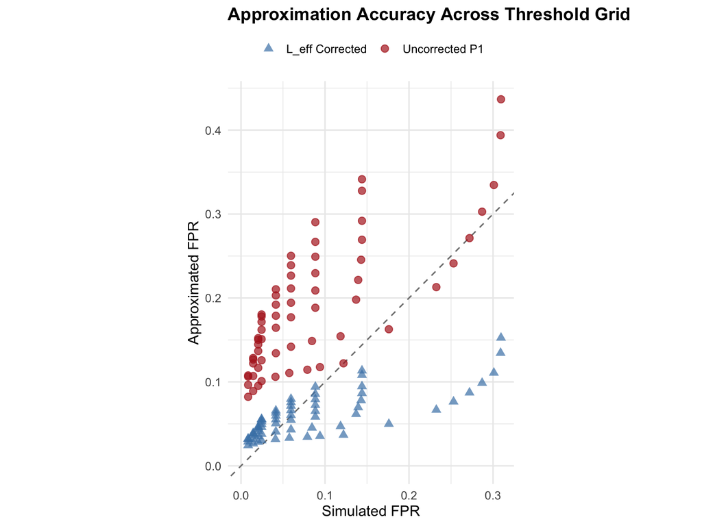

Approximation vs simulation across the (c1,c2) grid. Corrected points (triangles) should cluster near the diagonal.

```r
ggplot(grid_fpr, aes(x = FPR)) +
  geom_abline(slope = 1, intercept = 0, linetype = "dashed",
              colour = "grey50") +
  geom_point(aes(y = P1, colour = "Uncorrected P1"),
             size = 2.5, alpha = 0.7) +
  geom_point(aes(y = FPR_corr, colour = "L_eff Corrected"),
             size = 2.5, alpha = 0.7, shape = 17) +
  scale_colour_manual(values = c("Uncorrected P1" = "firebrick",
                                  "L_eff Corrected" = "steelblue")) +
  coord_equal(xlim = c(0, max(grid_fpr$FPR, 0.25)),
              ylim = c(0, max(grid_fpr$P1, 0.25))) +
  labs(x = "Simulated FPR", y = "Approximated FPR",
       title = "Approximation Accuracy Across Threshold Grid",
       colour = NULL) +
  theme_minimal(base_size = 12) +
  theme(legend.position = "top",
        plot.title = element_text(face = "bold"))
```

## 8.7 Acceptable Region (FPR $\le$ 12%)

```r
acceptable_grid <- grid_fpr[FPR <= fpr_target]
setorder(acceptable_grid, FPR)

if (nrow(acceptable_grid) > 0) {
  gt_acc <- gt(acceptable_grid[, .(c1, c2,
    `Sim FPR` = sprintf("%.1f%%", 100 * FPR),
    `P1 (uncorr)` = sprintf("%.1f%%", 100 * P1),
    `FPR (corr)` = sprintf("%.1f%%", 100 * FPR_corr))]) |>
    tab_header(
      title = md(sprintf(
        "**Acceptable Threshold Configurations (FPR <= %.0f%%)**",
        100 * fpr_target)),
      subtitle = sprintf("N=%d, GBSG survival DGM, n.min=%d",
                          N_grid, n_min_val)
    ) |>
    tab_source_note("Paper defaults: c1=1.25, c2=1.0")
  knitr::asis_output(gt::as_raw_html(gt_acc))
} else {
  cat(sprintf("No configurations achieved FPR <= %.0f%% in this grid.\n",
              100 * fpr_target))
}
```

Threshold pairs with simulated FPR <= 12%

**Acceptable Threshold Configurations (FPR <= 12%)**

N=700, GBSG survival DGM, n.min=60

| c1 | c2 | Sim FPR | P1 (uncorr) | FPR (corr) |
| --- | --- | --- | --- | --- |
| 1.25 | 1.25 | 0.9% | 10.8% | 3.2% |
| 1.30 | 1.25 | 0.9% | 10.6% | 3.2% |
| 1.40 | 1.25 | 0.9% | 9.6% | 2.9% |
| 1.50 | 1.25 | 0.9% | 8.2% | 2.4% |
| 1.20 | 1.20 | 1.5% | 12.9% | 3.9% |
| 1.25 | 1.20 | 1.5% | 12.7% | 3.8% |
| 1.30 | 1.20 | 1.5% | 12.2% | 3.7% |
| 1.40 | 1.20 | 1.5% | 10.7% | 3.2% |
| 1.50 | 1.20 | 1.5% | 8.9% | 2.7% |
| 1.15 | 1.15 | 2.1% | 15.2% | 4.6% |
| 1.20 | 1.15 | 2.1% | 15.0% | 4.6% |
| 1.25 | 1.15 | 2.1% | 14.5% | 4.4% |
| 1.30 | 1.15 | 2.1% | 13.7% | 4.2% |
| 1.40 | 1.15 | 2.1% | 11.7% | 3.5% |
| 1.50 | 1.15 | 2.1% | 9.5% | 2.8% |
| 1.10 | 1.10 | 2.5% | 18.0% | 5.6% |
| 1.15 | 1.10 | 2.5% | 17.8% | 5.5% |
| 1.20 | 1.10 | 2.5% | 17.2% | 5.3% |
| 1.25 | 1.10 | 2.5% | 16.2% | 5.0% |
| 1.30 | 1.10 | 2.5% | 15.1% | 4.6% |
| 1.40 | 1.10 | 2.5% | 12.6% | 3.8% |
| 1.50 | 1.10 | 2.5% | 10.1% | 3.0% |
| 1.50 | 1.05 | 4.1% | 10.6% | 3.2% |
| 1.10 | 1.05 | 4.2% | 21.0% | 6.6% |
| 1.15 | 1.05 | 4.2% | 20.3% | 6.3% |
| 1.20 | 1.05 | 4.2% | 19.2% | 6.0% |
| 1.25 | 1.05 | 4.2% | 17.9% | 5.5% |
| 1.30 | 1.05 | 4.2% | 16.5% | 5.1% |
| 1.40 | 1.05 | 4.2% | 13.4% | 4.1% |
| 1.50 | 1.00 | 5.8% | 11.1% | 3.3% |
| 1.00 | 1.00 | 5.9% | 25.0% | 8.0% |
| 1.10 | 1.00 | 5.9% | 23.9% | 7.6% |
| 1.15 | 1.00 | 5.9% | 22.7% | 7.1% |
| 1.20 | 1.00 | 5.9% | 21.1% | 6.6% |
| 1.25 | 1.00 | 5.9% | 19.4% | 6.0% |
| 1.30 | 1.00 | 5.9% | 17.7% | 5.5% |
| 1.40 | 1.00 | 5.9% | 14.2% | 4.3% |
| 1.50 | 0.95 | 7.9% | 11.4% | 3.4% |
| 1.40 | 0.95 | 8.5% | 14.9% | 4.5% |
| 1.00 | 0.95 | 8.8% | 29.0% | 9.4% |
| 1.10 | 0.95 | 8.8% | 26.7% | 8.6% |
| 1.15 | 0.95 | 8.8% | 24.9% | 7.9% |
| 1.20 | 0.95 | 8.8% | 23.0% | 7.2% |
| 1.25 | 0.95 | 8.8% | 20.9% | 6.5% |
| 1.30 | 0.95 | 8.8% | 18.8% | 5.8% |
| 1.50 | 0.90 | 9.4% | 11.8% | 3.5% |
| 1.40 | 0.90 | 11.8% | 15.4% | 4.7% |

Paper defaults: c1=1.25, c2=1.0

# 9 Summary

```r
# ── Key configurations ────────────────────────────────────────
paper_row   <- grid_fpr[c1 == 1.25 & c2 == 1.00]
target_band <- grid_fpr[FPR >= 0.08 & FPR <= fpr_target]
setorder(target_band, -FPR)
conservative <- grid_fpr[FPR <= 0.10]
setorder(conservative, c1, c2)

# Build display table: paper default + target band + conservative
make_row <- function(dt, label) {
  if (nrow(dt) == 0) return(NULL)
  dt[, .(
    Region   = label,
    c1       = c1,
    c2       = c2,
    `Sim FPR`   = sprintf("%.1f%%", 100 * FPR),
    `P1`        = sprintf("%.1f%%", 100 * P1),
    `FPR_corr`  = sprintf("%.1f%%", 100 * FPR_corr),
    `Sim/Corr`  = round(Sim_over_Corr, 2),
    fpr_num     = FPR   # numeric column for gt row predicates
  )]
}

summary_dt <- rbind(
  make_row(paper_row,   "Paper default"),
  make_row(target_band, sprintf("Target band (8-%d%%)", round(100 * fpr_target))),
  make_row(conservative,"Conservative (FPR <= 10%)")
)

if (is.null(summary_dt) || nrow(summary_dt) == 0) {
  cat("No rows met any of the three FPR criteria at this grid resolution.\n")
} else {
  target_label <- sprintf("Target band (8-%d%%)", round(100 * fpr_target))
  gt_out <- gt(summary_dt) |>
    tab_header(
      title = md("**Null Operating Characteristics Summary**"),
      subtitle = sprintf(
        "GBSG survival DGM | N=%d | n.min=%d | pcons=%.2f | L_eff=%.2f",
        N_grid, n_min_val, pcons, L_eff_N)
    ) |>
    tab_row_group(label = "Conservative (FPR \u2264 10%)",
      rows = Region == "Conservative (FPR <= 10%)") |>
    tab_row_group(label = sprintf("Target band (8\u2013%d%%)", round(100*fpr_target)),
      rows = Region == target_label) |>
    tab_row_group(label = "Paper default (c1=1.25, c2=1.0)",
      rows = Region == "Paper default") |>
    cols_hide(columns = c(Region, fpr_num)) |>
    tab_style(style = cell_fill(color = "#E8F5E9"),
      locations = cells_body(columns = `Sim FPR`,
        rows = fpr_num <= fpr_target)) |>
    tab_source_note(paste(
      "L_eff note: for survival, L_eff < 1 is common because events-based filters",
      "(d0.min, d1.min) aggressively prune candidates,",
      "making paper defaults already conservative for survival endpoints."))
  knitr::asis_output(gt::as_raw_html(gt_out))
}
```

**Null Operating Characteristics Summary**

GBSG survival DGM | N=700 | n.min=60 | pcons=0.90 | L_eff=0.29

| c1 | c2 | Sim FPR | P1 | FPR_corr | Sim/Corr |
| --- | --- | --- | --- | --- | --- |
| Paper default (c1=1.25, c2=1.0) |  |  |  |  |  |
| 1.25 | 1.00 | 5.9% | 19.4% | 6.0% | 0.98 |
| Target band (8–12%) |  |  |  |  |  |
| 1.40 | 0.90 | 11.8% | 15.4% | 4.7% | 2.51 |
| 1.50 | 0.90 | 9.4% | 11.8% | 3.5% | 2.65 |
| 1.00 | 0.95 | 8.8% | 29.0% | 9.4% | 0.94 |
| 1.10 | 0.95 | 8.8% | 26.7% | 8.6% | 1.03 |
| 1.15 | 0.95 | 8.8% | 24.9% | 7.9% | 1.12 |
| 1.20 | 0.95 | 8.8% | 23.0% | 7.2% | 1.22 |
| 1.25 | 0.95 | 8.8% | 20.9% | 6.5% | 1.35 |
| 1.30 | 0.95 | 8.8% | 18.8% | 5.8% | 1.52 |
| 1.40 | 0.95 | 8.5% | 14.9% | 4.5% | 1.86 |
| Conservative (FPR ≤ 10%) |  |  |  |  |  |
| 1.00 | 0.95 | 8.8% | 29.0% | 9.4% | 0.94 |
| 1.00 | 1.00 | 5.9% | 25.0% | 8.0% | 0.75 |
| 1.10 | 0.95 | 8.8% | 26.7% | 8.6% | 1.03 |
| 1.10 | 1.00 | 5.9% | 23.9% | 7.6% | 0.79 |
| 1.10 | 1.05 | 4.2% | 21.0% | 6.6% | 0.63 |
| 1.10 | 1.10 | 2.5% | 18.0% | 5.6% | 0.44 |
| 1.15 | 0.95 | 8.8% | 24.9% | 7.9% | 1.12 |
| 1.15 | 1.00 | 5.9% | 22.7% | 7.1% | 0.83 |
| 1.15 | 1.05 | 4.2% | 20.3% | 6.3% | 0.66 |
| 1.15 | 1.10 | 2.5% | 17.8% | 5.5% | 0.45 |
| 1.15 | 1.15 | 2.1% | 15.2% | 4.6% | 0.44 |
| 1.20 | 0.95 | 8.8% | 23.0% | 7.2% | 1.22 |
| 1.20 | 1.00 | 5.9% | 21.1% | 6.6% | 0.90 |
| 1.20 | 1.05 | 4.2% | 19.2% | 6.0% | 0.70 |
| 1.20 | 1.10 | 2.5% | 17.2% | 5.3% | 0.46 |
| 1.20 | 1.15 | 2.1% | 15.0% | 4.6% | 0.45 |
| 1.20 | 1.20 | 1.5% | 12.9% | 3.9% | 0.37 |
| 1.25 | 0.95 | 8.8% | 20.9% | 6.5% | 1.35 |
| 1.25 | 1.00 | 5.9% | 19.4% | 6.0% | 0.98 |
| 1.25 | 1.05 | 4.2% | 17.9% | 5.5% | 0.75 |
| 1.25 | 1.10 | 2.5% | 16.2% | 5.0% | 0.49 |
| 1.25 | 1.15 | 2.1% | 14.5% | 4.4% | 0.47 |
| 1.25 | 1.20 | 1.5% | 12.7% | 3.8% | 0.38 |
| 1.25 | 1.25 | 0.9% | 10.8% | 3.2% | 0.26 |
| 1.30 | 0.95 | 8.8% | 18.8% | 5.8% | 1.52 |
| 1.30 | 1.00 | 5.9% | 17.7% | 5.5% | 1.09 |
| 1.30 | 1.05 | 4.2% | 16.5% | 5.1% | 0.82 |
| 1.30 | 1.10 | 2.5% | 15.1% | 4.6% | 0.53 |
| 1.30 | 1.15 | 2.1% | 13.7% | 4.2% | 0.49 |
| 1.30 | 1.20 | 1.5% | 12.2% | 3.7% | 0.39 |
| 1.30 | 1.25 | 0.9% | 10.6% | 3.2% | 0.27 |
| 1.40 | 0.95 | 8.5% | 14.9% | 4.5% | 1.86 |
| 1.40 | 1.00 | 5.9% | 14.2% | 4.3% | 1.38 |
| 1.40 | 1.05 | 4.2% | 13.4% | 4.1% | 1.02 |
| 1.40 | 1.10 | 2.5% | 12.6% | 3.8% | 0.64 |
| 1.40 | 1.15 | 2.1% | 11.7% | 3.5% | 0.58 |
| 1.40 | 1.20 | 1.5% | 10.7% | 3.2% | 0.45 |
| 1.40 | 1.25 | 0.9% | 9.6% | 2.9% | 0.29 |
| 1.50 | 0.90 | 9.4% | 11.8% | 3.5% | 2.65 |
| 1.50 | 0.95 | 7.9% | 11.4% | 3.4% | 2.29 |
| 1.50 | 1.00 | 5.8% | 11.1% | 3.3% | 1.73 |
| 1.50 | 1.05 | 4.1% | 10.6% | 3.2% | 1.29 |
| 1.50 | 1.10 | 2.5% | 10.1% | 3.0% | 0.81 |
| 1.50 | 1.15 | 2.1% | 9.5% | 2.8% | 0.72 |
| 1.50 | 1.20 | 1.5% | 8.9% | 2.7% | 0.55 |
| 1.50 | 1.25 | 0.9% | 8.2% | 2.4% | 0.35 |

L_eff note: for survival, L_eff < 1 is common because events-based filters (d0.min, d1.min) aggressively prune candidates, making paper defaults already conservative for survival endpoints.

# 10 Save All Simulation Results

```r
if (!dir.exists(output_dir)) dir.create(output_dir, recursive = TRUE)

sim_bundle <- list(

  # Metadata
  params = list(
    nsims_null = nsims_null,
    nsims_grid = nsims_grid,
    n_sims_cal = nsims_cal,
    sim_seed = sim_seed,
    N_grid = N_grid,
    N_cal_values = N_cal_values,
    sim_config = sim_config,
    fs_params_base = fs_params_base,
    fs_params_cox = fs_params_cox,
    fs_params_irr = fs_params_irr,
    c1_grid = c1_grid,
    c2_grid = c2_grid,
    n_min_val = n_min_val,
    prop_cens = prop_cens,
    p_harm = p_harm,
    hr_h1 = hr_h1,
    fpr_target = fpr_target,
    timestamp = Sys.time(),
    R_version = R.version.string,
    forestsearch_version = tryCatch(
      as.character(utils::packageVersion("forestsearch")),
      error = function(e) "unknown")
  ),

  # DGM
  dgm_null = dgm_null,

  # Paper-defaults null sims (Part II)
  results_null_cox = results_null_cox,
  results_null_irr = results_null_irr,

  # L_eff calibration (Part III)
  leff = list(
    C = C_fit,
    alpha = alpha_fit,
    n_min = n_min_val,
    cal_df = cal_df
  ),

  # Grid sweep results (Part IV)
  grid_results = grid_results,
  grid_fpr = grid_fpr,

  # Timing
  timings = timings
)

rds_path <- file.path(output_dir,
  sprintf("calibration_survival_leff_grid_%s.rds",
          format(Sys.Date(), "%Y%m%d")))
saveRDS(sim_bundle, rds_path)

cat(sprintf("=== All results saved ===\n"))
```

```
#> === All results saved ===
```

```r
cat(sprintf("  File: %s\n", rds_path))
```

```
#>   File: ../_data/calibration_survival_leff_grid_20260416.rds
```

```r
cat(sprintf("  Size: %.1f MB\n", file.size(rds_path) / 1024^2))
```

```
#>   Size: 0.7 MB
```

```r
cat(sprintf("  Contents:\n"))
```

```
#>   Contents:
```

```r
cat(sprintf("    results_null_cox: %d rows\n", nrow(results_null_cox)))
```

```
#>     results_null_cox: 2000 rows
```

```r
cat(sprintf("    results_null_irr: %d rows\n", nrow(results_null_irr)))
```

```
#>     results_null_irr: 2000 rows
```

```r
cat(sprintf("    cal_df:           %d rows (N = %s)\n",
            nrow(cal_df), paste(cal_df$N, collapse = ", ")))
```

```
#>     cal_df:           3 rows (N = 300, 500, 700)
```

```r
cat(sprintf("    grid_results:     %d rows (%d configs x %d sims)\n",
            nrow(grid_results), nrow(grid_pairs), nsims_grid))
```

```
#>     grid_results:     126000 rows (63 configs x 2000 sims)
```

```r
cat(sprintf("    grid_fpr:         %d (c1,c2) pairs\n", nrow(grid_fpr)))
```

```
#>     grid_fpr:         63 (c1,c2) pairs
```

```r
cat(sprintf("    L_eff:            C=%.4f, alpha=%.4f\n",
            C_fit, alpha_fit))
```

```
#>     L_eff:            C=0.3377, alpha=-0.0643
```

## 10.1 How to Reload

```r
res <- readRDS(latest_rds("calibration_survival_leff_grid"))

# Paper-defaults FPR
cox_h0 <- res$results_null_cox[res$results_null_cox$analysis == "FS", ]
cat("Cox H0 FPR:", mean(cox_h0$any.H), "\n")

# L_eff calibration
res$leff$C            # fitted C
res$leff$alpha        # fitted alpha
res$leff$cal_df       # raw calibration points

# Grid sweep
res$grid_fpr          # FPR by (c1, c2)
res$grid_fpr[FPR <= res$params$fpr_target]   # acceptable configs

# Config
res$params$nsims_null       # how many sims
res$params$c1_grid          # which thresholds swept
res$params$fpr_target       # FPR target
```

# 11 Timing and Session Info

```r
timings$total <- (proc.time() - t_vignette_start)["elapsed"]

# ── Per-call wall-clock rates ─────────────────────────────────
# All times are already parallelised wall-clock seconds.
n_tasks_cox  <- nsims_null
n_tasks_irr  <- nsims_null
n_tasks_cal  <- nsims_cal * length(N_cal_values)
n_tasks_grid <- nsims_grid * nrow(grid_pairs)

rate_cox  <- timings$null_cox  / n_tasks_cox
rate_irr  <- timings$null_irr  / n_tasks_irr
rate_cal  <- timings$null_cal  / n_tasks_cal
rate_grid <- timings$null_grid / n_tasks_grid

# ── Actual run ────────────────────────────────────────────────
timing_df <- data.frame(
  Stage = c(
    sprintf("DGM setup"),
    sprintf("Cox H0 — paper defaults (%d sims)", nsims_null),
    sprintf("IRR H0 — paper defaults (%d sims)", nsims_null),
    sprintf("L_eff calibration (%d sims × %d N)", nsims_cal, length(N_cal_values)),
    sprintf("Null grid sweep (%d sims × %d pairs)", nsims_grid, nrow(grid_pairs)),
    "Total (including rendering)"
  ),
  Seconds = c(
    timings$dgm, timings$null_cox, timings$null_irr,
    timings$null_cal, timings$null_grid, timings$total),
  stringsAsFactors = FALSE
)
timing_df$Minutes <- timing_df$Seconds / 60
timing_df$Hours   <- timing_df$Seconds / 3600

# ── Per-call rates row ────────────────────────────────────────
rates_row <- data.frame(
  Stage   = sprintf("Wall-clock per FS call (%d workers): Cox %.2fs | IRR %.2fs | Grid %.2fs",
                     n_workers, rate_cox, rate_irr, rate_grid),
  Seconds = NA_real_, Minutes = NA_real_, Hours = NA_real_,
  stringsAsFactors = FALSE)

# ── Production projection ─────────────────────────────────────
proj_cox   <- rate_cox  * nsims_prod_null
proj_irr   <- rate_irr  * nsims_prod_null
proj_cal   <- rate_cal  * nsims_prod_cal * length(N_cal_values)
proj_grid  <- rate_grid * nsims_prod_grid * nrow(grid_pairs)
proj_total <- proj_cox + proj_irr + proj_cal + proj_grid + timings$dgm

prod_row <- data.frame(
  Stage   = sprintf("Production estimate: %d null / %d cal / %d grid  (%d pairs)",
                     nsims_prod_null, nsims_prod_cal, nsims_prod_grid, nrow(grid_pairs)),
  Seconds = proj_total,
  Minutes = proj_total / 60,
  Hours   = proj_total / 3600,
  stringsAsFactors = FALSE)

timing_df <- rbind(timing_df, rates_row, prod_row)

gt(timing_df) |>
  tab_header(
    title = "Computational Timing Summary",
    subtitle = sprintf(
      "%d workers | grid: %d pairs × %d sims | cal: %d sims × %d N",
      n_workers, nrow(grid_pairs), nsims_grid,
      nsims_cal, length(N_cal_values))
  ) |>
  fmt_number(columns = Seconds, decimals = 1, rows = !is.na(Seconds)) |>
  fmt_number(columns = Minutes, decimals = 2, rows = !is.na(Minutes)) |>
  fmt_number(columns = Hours,   decimals = 3, rows = !is.na(Hours))   |>
  cols_label(Stage = "Stage", Seconds = "Time (sec)",
             Minutes = "Time (min)", Hours = "Time (hr)") |>
  tab_style(style = cell_text(weight = "bold"),
    locations = cells_body(rows = grepl("Total|Production", Stage))) |>
  tab_style(style = cell_fill(color = "#E8F5E9"),
    locations = cells_body(rows = grepl("Production", Stage))) |>
  tab_style(style = cell_fill(color = "#F1EFE8"),
    locations = cells_body(rows = grepl("Wall-clock", Stage))) |>
  tab_source_note(sprintf(
    "Production estimate: %d null + %d irr + %d cal×%dN + %d grid×%d pairs | same machine, same workers.",
    nsims_prod_null, nsims_prod_null, nsims_prod_cal, length(N_cal_values),
    nsims_prod_grid, nrow(grid_pairs)))
```

Computational Timing Summary

13 workers | grid: 63 pairs × 2000 sims | cal: 1000 sims × 3 N

| Stage | Time (sec) | Time (min) | Time (hr) |
| --- | --- | --- | --- |
| DGM setup | 0.1 | 0.00 | 0.000 |
| Cox H0 — paper defaults (2000 sims) | 401.6 | 6.69 | 0.112 |
| IRR H0 — paper defaults (2000 sims) | 430.5 | 7.17 | 0.120 |
| L_eff calibration (1000 sims × 3 N) | 444.2 | 7.40 | 0.123 |
| Null grid sweep (2000 sims × 63 pairs) | 26,962.3 | 449.37 | 7.490 |
| Total (including rendering) | 28,245.1 | 470.75 | 7.846 |
| Wall-clock per FS call (13 workers): Cox 0.20s \| IRR 0.22s \| Grid 0.21s | NA | NA | NA |
| Production estimate: 4000 null / 2000 cal / 2000 grid (63 pairs) | 29,514.8 | 491.91 | 8.199 |

Production estimate: 4000 null + 4000 irr + 2000 cal×3N + 2000 grid×63 pairs | same machine, same workers.

```r
plan(sequential)
```

## 12 Appendix: Simulation Budget Guidance

The three simulation phases have independent precision requirements. The table below summarises the 95% confidence interval half-width for a simulated FPR estimate as a function of the number of replicates, together with the implied total task counts and recommended production targets.

```r
# ── Helper ────────────────────────────────────────────────────
ci_hw <- function(fpr, n, z = 1.96)
  z * sqrt(fpr * (1 - fpr) / n)

se_leff <- function(fpr, P1, n) {
  se_f <- sqrt(fpr * (1 - fpr) / n)
  se_f / (P1 * abs(log(1 - P1)))
}

cv_leff <- function(fpr, P1, n) {
  L <- log(1 - fpr) / log(1 - P1)
  100 * se_leff(fpr, P1, n) / L
}

# ── Parameters from this document ────────────────────────────
P1_ref   <- p_detect_glm(1.0, d_dgm, 1.25, 1.0)   # P1 at paper defaults
n_pairs  <- nrow(grid_pairs)                          # 63 pairs

# ── Part II: baseline null sims ───────────────────────────────
fpr_base <- c(mean(cox_h0$any.H), fpr_target)         # actual + target
fpr_ii   <- mean(fpr_base)                            # representative value

budget_ii <- data.frame(
  `nsims_null` = c(500L, 1000L, 2000L, 4000L),
  `95% CI ±(pp)` = round(100 * sapply(c(500,1000,2000,4000),
                    function(n) ci_hw(fpr_ii, n)), 1),
  check.names = FALSE
)

# ── Part III: L_eff calibration ───────────────────────────────
# Representative FPR at N=500 (middle cal point)
fpr_cal <- if (exists("cal_df") && nrow(cal_df) > 0)
  cal_df$sim_fpr[which.min(abs(cal_df$N - 500))] else 0.07

budget_iii <- data.frame(
  `nsims_cal` = c(200L, 500L, 1000L, 2000L),
  `CV of L_eff (%)` = round(sapply(c(200,500,1000,2000),
                       function(n) cv_leff(fpr_cal, P1_ref, n)), 0),
  check.names = FALSE
)

# ── Part IV: grid sweep ────────────────────────────────────────
budget_iv <- data.frame(
  `nsims_grid` = c(500L, 1000L, 2000L, 4000L),
  `95% CI ±(pp) @ FPR=10%` = round(100 * sapply(c(500,1000,2000,4000),
                              function(n) ci_hw(0.10, n)), 1),
  `95% CI ±(pp) @ FPR=5%`  = round(100 * sapply(c(500,1000,2000,4000),
                              function(n) ci_hw(0.05, n)), 1),
  `Total tasks (×%d pairs)` = c(500,1000,2000,4000) * n_pairs,
  check.names = FALSE
)
names(budget_iv)[4] <- sprintf("Total tasks (×%d pairs)", n_pairs)

# ── Recommended settings ──────────────────────────────────────
recs <- data.frame(
  Phase = c(
    "Part II — Baseline null (Cox + IRR)",
    "Part III — L_eff calibration",
    "Part IV — Grid sweep"
  ),
  Parameter = c("nsims_null", "nsims_cal", "nsims_grid"),
  `Current (actual)` = c(nsims_null, nsims_cal, nsims_grid),
  `Minimum` = c(2000L, 1000L, 2000L),
  `Production` = c(4000L, 2000L, 2000L),
  `Precision at production` = c(
    sprintf("±%.1fpp at FPR=%.0f%%",
            100 * ci_hw(fpr_ii, 4000), 100 * fpr_ii),
    sprintf("CV~%.0f%% on L_eff",
            cv_leff(fpr_cal, P1_ref, 2000)),
    sprintf("±%.1fpp at FPR=10%%",
            100 * ci_hw(0.10, 2000))
  ),
  check.names = FALSE
)

# ── Render tables ─────────────────────────────────────────────
tbl_recs <- gt(recs) |>
  tab_header(
    title = "Recommended Simulation Budgets",
    subtitle = sprintf(
      "GBSG survival DGM | %d cal N values | %d grid pairs | %d workers",
      length(N_cal_values), n_pairs, n_workers)
  ) |>
  tab_style(style = cell_fill(color = "#E8F5E9"),
    locations = cells_body(
      columns = Production,
      rows = `Current (actual)` >= Minimum)) |>
  tab_style(style = cell_fill(color = "#FFEBEE"),
    locations = cells_body(
      columns = `Current (actual)`,
      rows = `Current (actual)` < Minimum)) |>
  tab_source_note(paste(
    "Green: current setting meets or exceeds minimum.",
    "Red: current setting is below minimum — raise before production run.",
    sprintf("Part III note: C2 (calibration_survival_fourway.qmd) runs up to 20K sims/N",
            ""))) |>
  cols_label(`Current (actual)` = "Current")
knitr::asis_output(gt::as_raw_html(tbl_recs))
```

Recommended Simulation Budgets

GBSG survival DGM | 3 cal N values | 63 grid pairs | 13 workers

| Phase | Parameter | Current | Minimum | Production | Precision at production |
| --- | --- | --- | --- | --- | --- |
| Part II — Baseline null (Cox + IRR) | nsims_null | 2000 | 2000 | 4000 | ±0.9pp at FPR=9% |
| Part III — L_eff calibration | nsims_cal | 1000 | 1000 | 2000 | CV~42% on L_eff |
| Part IV — Grid sweep | nsims_grid | 2000 | 2000 | 2000 | ±1.3pp at FPR=10% |

Green: current setting meets or exceeds minimum. Red: current setting is below minimum — raise before production run. Part III note: C2 (calibration_survival_fourway.qmd) runs up to 20K sims/N

```r
cat("\n")
```

```r
# Detail tables
tbl_ii <- gt(budget_ii) |>
  tab_header(
    title = "Part II — Baseline Null Precision",
    subtitle = sprintf("Single threshold pair | representative FPR = %.1f%%",
                        100 * fpr_ii)
  ) |>
  tab_style(style = cell_fill(color = "#E8F5E9"),
    locations = cells_body(rows = `nsims_null` >= 2000L)) |>
  tab_source_note("Green: meets minimum. 2,000 = minimum; 4,000 = production.")

tbl_iii <- gt(budget_iii) |>
  tab_header(
    title = "Part III — L_eff Calibration Precision",
    subtitle = sprintf(
      "3-point power-law fit | P1=%.3f at paper defaults | FPR~%.1f%% at N=500",
      P1_ref, 100 * fpr_cal)
  ) |>
  tab_style(style = cell_fill(color = "#E8F5E9"),
    locations = cells_body(rows = `nsims_cal` >= 1000L)) |>
  tab_source_note(paste(
    "CV is high because L_eff < 1 for survival (events-based pruning).",
    "C2 is the primary calibration source; C3 is a cross-check.",
    "1,000 = minimum standalone; 2,000 = production standalone."))

tbl_iv <- gt(budget_iv) |>
  tab_header(
    title = "Part IV — Grid Sweep Precision",
    subtitle = sprintf(
      "%d threshold pairs | boundary detection requires CI < 2-3pp gap",
      n_pairs)
  ) |>
  tab_style(style = cell_fill(color = "#E8F5E9"),
    locations = cells_body(rows = `nsims_grid` >= 2000L)) |>
  tab_source_note(
    "2,000 sims/pair: ±1.3pp at FPR=10% — adequate for boundary classification.")

knitr::asis_output(gt::as_raw_html(tbl_ii))
```

Part II — Baseline Null Precision

Single threshold pair | representative FPR = 9.0%

| nsims_null | 95% CI ±(pp) |
| --- | --- |
| 500 | 2.5 |
| 1000 | 1.8 |
| 2000 | 1.3 |
| 4000 | 0.9 |

Green: meets minimum. 2,000 = minimum; 4,000 = production.

```r
cat("\n")
```

```r
knitr::asis_output(gt::as_raw_html(tbl_iii))
```

Part III — L_eff Calibration Precision

3-point power-law fit | P1=0.194 at paper defaults | FPR~6.6% at N=500

| nsims_cal | CV of L_eff (%) |
| --- | --- |
| 200 | 132 |
| 500 | 84 |
| 1000 | 59 |
| 2000 | 42 |

CV is high because L_eff < 1 for survival (events-based pruning). C2 is the primary calibration source; C3 is a cross-check. 1,000 = minimum standalone; 2,000 = production standalone.

```r
cat("\n")
```

```r
knitr::asis_output(gt::as_raw_html(tbl_iv))
```

Part IV — Grid Sweep Precision

63 threshold pairs | boundary detection requires CI < 2-3pp gap

| nsims_grid | 95% CI ±(pp) @ FPR=10% | 95% CI ±(pp) @ FPR=5% | Total tasks (×63 pairs) |
| --- | --- | --- | --- |
| 500 | 2.6 | 1.9 | 31500 |
| 1000 | 1.9 | 1.4 | 63000 |
| 2000 | 1.3 | 1.0 | 126000 |
| 4000 | 0.9 | 0.7 | 252000 |

2,000 sims/pair: ±1.3pp at FPR=10% — adequate for boundary classification.

Simulation budget guidance: 95% CI half-width for simulated FPR by phase and replicate count.